# PSYC40940: Foundations of Data Visualisation and ggplot2

## General outline for weeks 2 – 5

- Week 2: Principles of data visualisation
- Week 3: Grammar of graphics; aesthetics and attributes
- Week 4: Major visualisation tools
- Week 5: Customising visualisations (scales, themes, and labels)

## Overview

- Motivation / Relevance
- `ggplot2` teaser
- Principles of data visualisation

Download [“Exercises” folder](https://now.ntu.ac.uk/d2l/le/lessons/1111404/topics/14295810) from NOW Learning Room (week 2). Move files into R-Project folder.

## The data

- Picture naming task
- Written and spoken responses
- Manipulation: Prior familiarisation with most-common name for a picture

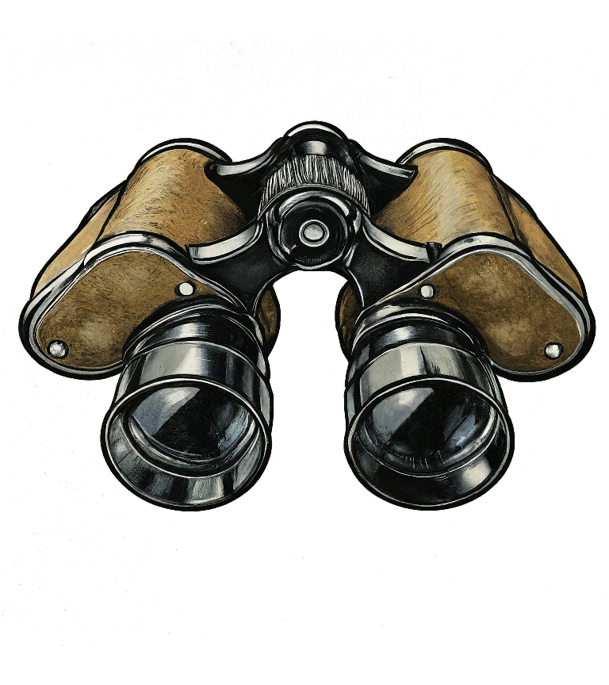

## Exploring data

[output not shown]

## Exploring data

```r
d_ppt_pic <- distinct(d_spellname, ppt_id, image_id)
count(d_ppt_pic, ppt_id)
```

```
# A tibble: 72 × 2
   ppt_id     n
    <dbl> <int>
 1      1   141
 2      2   132
 3      3   142
 4      4   139
 5      5   136
 6      6   132
 7      7   137
 8      8   141
 9      9   142
10     10   136
# ℹ 62 more rows
```

## What is data visualisation?

- Graphical representation of data
- Graphical data analysis
- What do we want to know?
- What do we want to communicate?
- What do people take away from your visualisation?
- Exploratory plots (for small specialist audience)
- Explanatory plots: inform and persuade wider audience

## Building up a plot

```r
d_vocab <- summarise(d_spellname,
                      rt = mean(rt),
                      .by = c(ppt_id, ppt_vocab, modality))
glimpse(d_vocab, width = 120)
```

```
Rows: 72
Columns: 4
$ ppt_id    <dbl> 40, 41, 42, 43, 44, 45, 46, 47, 48, 50, 51, 52, 53, 54, 55, 56, 57, 58, 59, 60, 62, 63, 64, 65, 66, …
$ ppt_vocab <dbl> 0.9500, 1.0000, 0.9250, 0.9000, 0.9750, 1.0000, 0.9250, 0.9625, 0.9750, 0.8250, 0.9375, 0.8875, 0.97…
$ modality  <chr> "speech", "speech", "speech", "speech", "speech", "speech", "speech", "speech", "speech", "speech", …
$ rt        <dbl> 1358.0756, 1273.9292, 1392.7664, 735.4684, 1188.0392, 1345.2583, 1519.9000, 1512.6337, 1479.2810, 12…
```

## Building up a plot

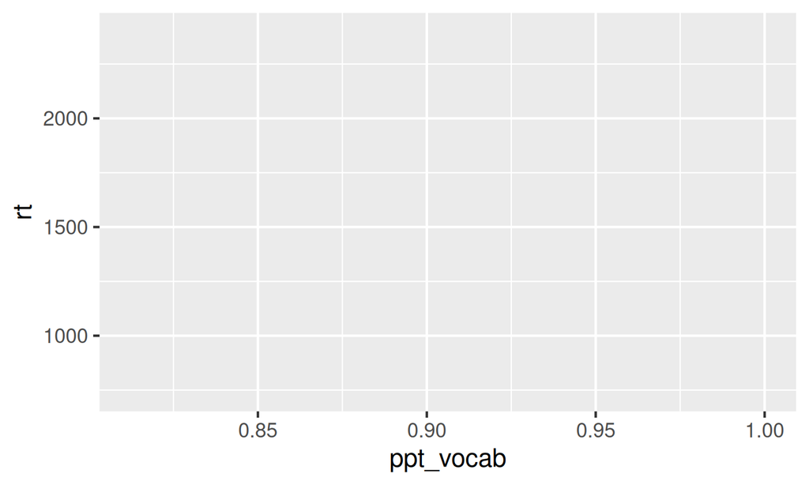

```r
ggplot(data = d_vocab,
       mapping = aes(x = ppt_vocab,
                     y = rt))
```

## Building up a plot

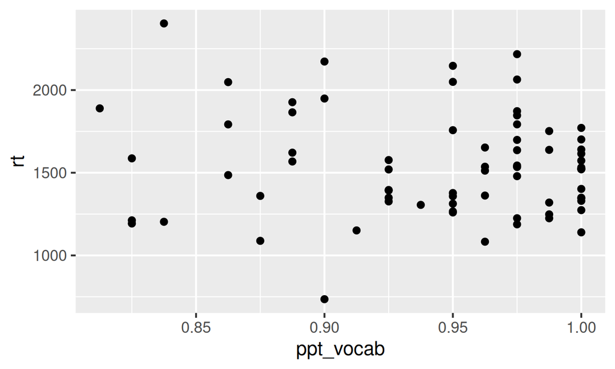

```r
ggplot(data = d_vocab,
       mapping = aes(x = ppt_vocab,
                     y = rt))  +
  geom_point()
```

## Building up a plot

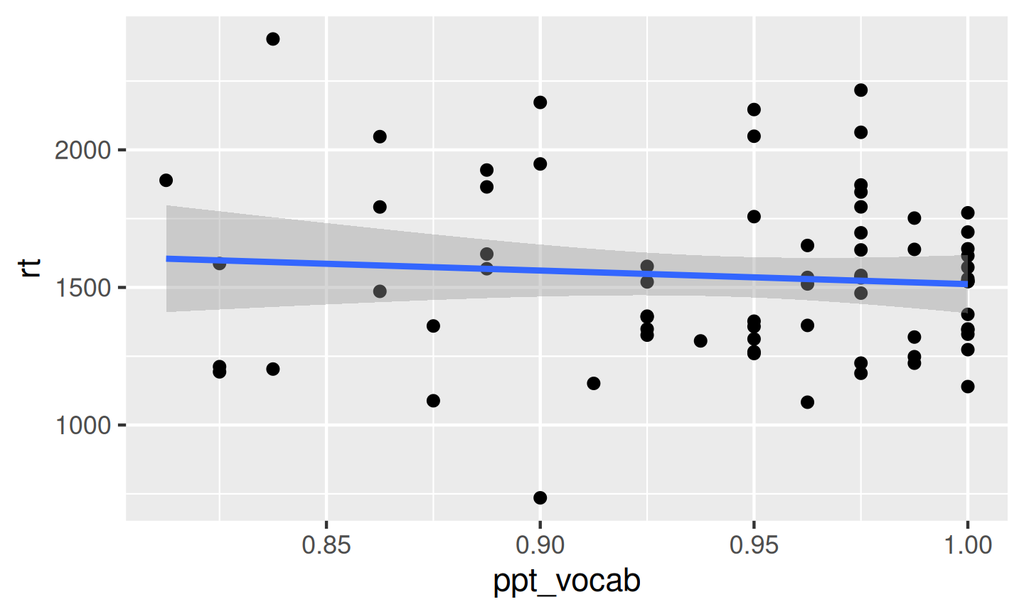

```r
ggplot(data = d_vocab,
       mapping = aes(x = ppt_vocab,
                     y = rt)) +
  geom_point() +
  stat_smooth(method = "lm")
```

## Building up a plot

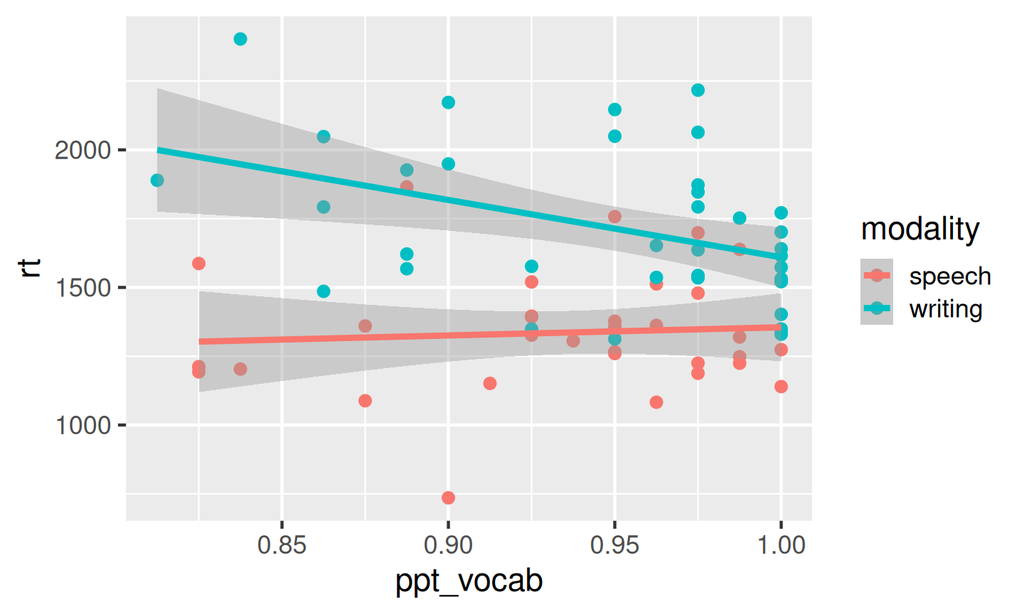

```r
ggplot(data = d_vocab,
       mapping = aes(x = ppt_vocab,
                     y = rt,
                     colour = modality)) +
  geom_point() +
  stat_smooth(method = "lm")
```

## Building up a plot

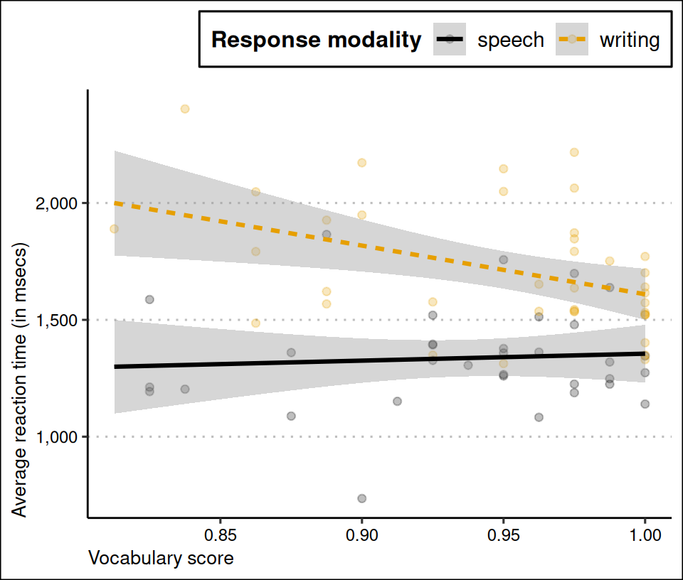

```r
ggplot(data = d_vocab,
       mapping = aes(x = ppt_vocab,
                     y = rt,
                     colour = modality,
                     linetype = modality))  +
  geom_point(alpha = .25) +
  stat_smooth(method = "lm", se = T, fullrange = TRUE) +
  scale_y_continuous(labels = scales::comma) +
  ggthemes::theme_clean() +
  ggthemes::scale_color_colorblind() +
  labs(y = "Average reaction time (in msecs)",
       x = "Vocabulary score",
       colour = "Response modality",
       linetype = "Response modality") +
  theme(legend.position = "top",
        legend.justification = "right",
        axis.title = element_text(hjust = 0))
```

## Creating an exploratory plot

Open RMarkdown document **1_scatterplots.Rmd**

## Why data visualisation?

### “[data visualization] forces us to notice what we never expected to see.” (Tukey, 1977)

- exploring structures in the data
- relationship between variables
- distribution of data
- develop an understanding of patterns (beyond means and SDs)
- selecting appropriate stats
- prevent wrong conclusions about data / theory

## Anscombe’s quartet (Anscombe, 1973)

| Data set | x Mean | x SD | y Mean | y SD | y ~ x Correlation | y ~ x Intercept | y ~ x Slope |
| --- | --- | --- | --- | --- | --- | --- | --- |
| 1 | 9 | 3.32 | 7.5 | 2.03 | 0.82 | 3 | 0.5 |
| 2 | 9 | 3.32 | 7.5 | 2.03 | 0.82 | 3 | 0.5 |
| 3 | 9 | 3.32 | 7.5 | 2.03 | 0.82 | 3 | 0.5 |
| 4 | 9 | 3.32 | 7.5 | 2.03 | 0.82 | 3 | 0.5 |

## Anscombe’s quartet

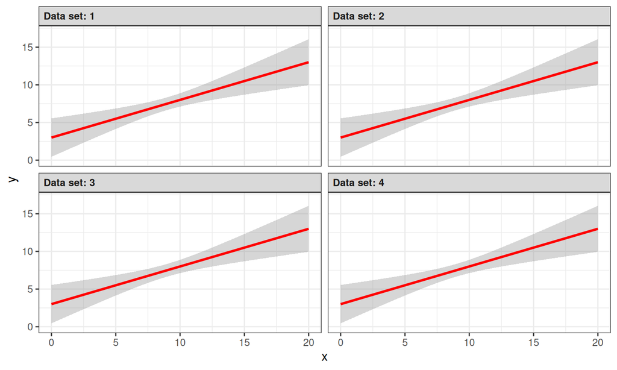

## Anscombe’s quartet

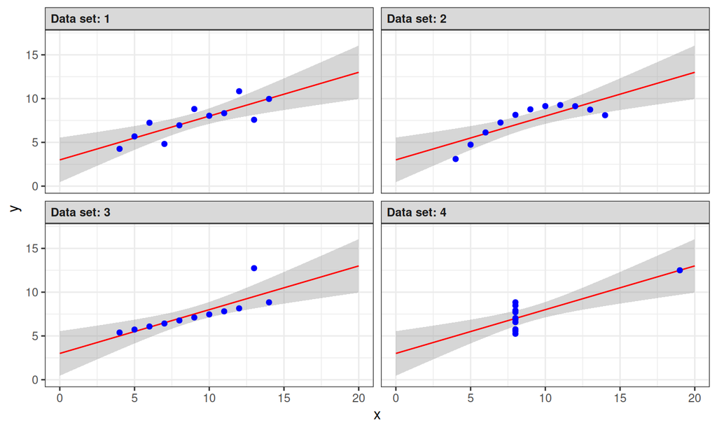

## The datasaurus dozen

### Matejka & Fitzmaurice (2017): [see link](https://www.autodeskresearch.com/publications/samestats)

Open RMarkdown document: **2_tdd.Rmd**

## Principles of data visualisation

- No “one fits all” method
- Some methods are more informative than others
- Maximise what we can learn from data
- Going beyond summary statistics
- Descriptive summary statistics may conceal / obscure important patterns but minimise what we want to communicate
- Visualisation helps us to understand patterns, structures, relationships
- Prevent wrong conclusions about data / theory

## Principles of data visualisation

Hartwig & Dearing (1979):

- *Skepticism:* any visualization might obscure or misrepresent data
- *Openness:* there might be patterns and structures that we were not expecting

Tufte (1983):

- Above all else show the data
- Avoid distorting what the data have to say
- Present many numbers in a small space
- Encourage the eye to compare different pieces of data
- Reveal data at several levels of detail, from broad overview to fine structures

## 6 plots of the same data

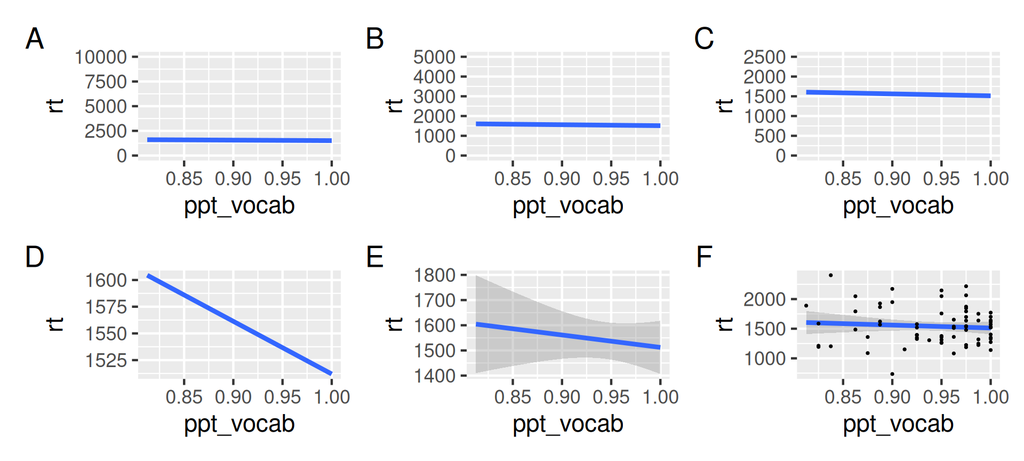

## Obscuring data and misleading information

Open RMarkdown document **3_scatterplots.Rmd**

## Principles of data visualisation

Edward Tufte’s principles emphasise clarity, precision, and efficiency in the visual display of information. Tufte’s principles guide us to create visualizations that are:

- Clear
- Honest
- Efficient
- Insightful

## Principles of data visualisation

**Principle 1:** Show the Data

- Focus on the data itself
- Avoid unnecessary decoration
- Let the data tell the story

**Principle 2:** Maximize Data-Ink Ratio

- Minimize non-essential elements
- Every visual element should serve a purpose

**Principle 3:** Avoid Chartjunk

- Eliminate decorative elements that obscure the message
- Simplicity and clarity are key

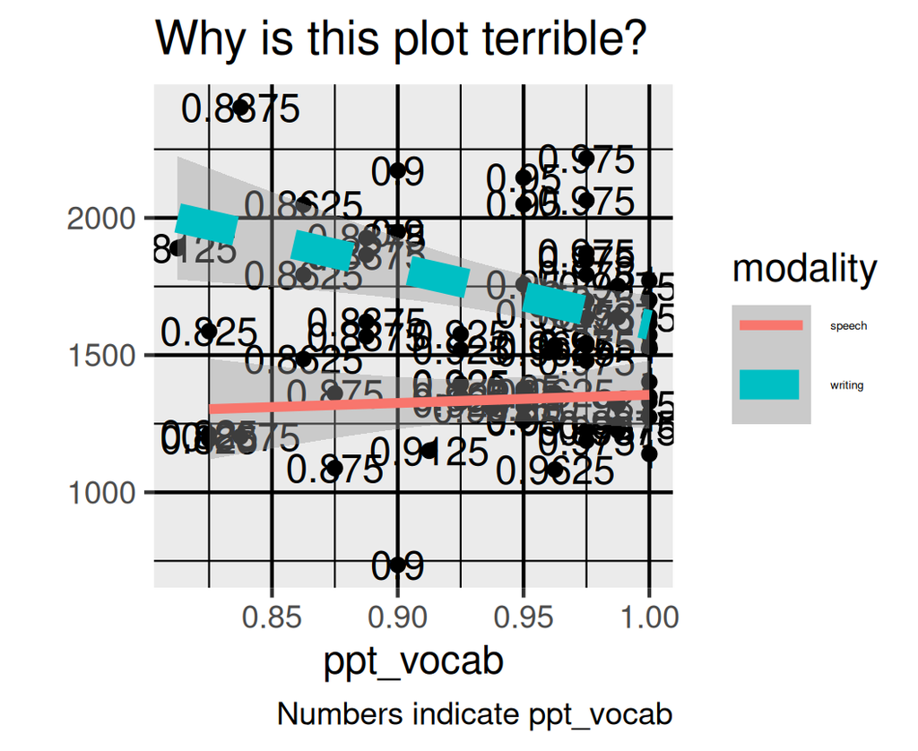

## Principles of data visualisation

**Principle 1:** Show the Data

- Focus on the data itself
- Avoid unnecessary decoration
- Let the data tell the story

**Principle 2:** Maximize Data-Ink Ratio

- Minimize non-essential elements
- Every visual element should serve a purpose

**Principle 3:** Avoid Chartjunk

- Eliminate decorative elements that obscure the message
- Simplicity and clarity are key

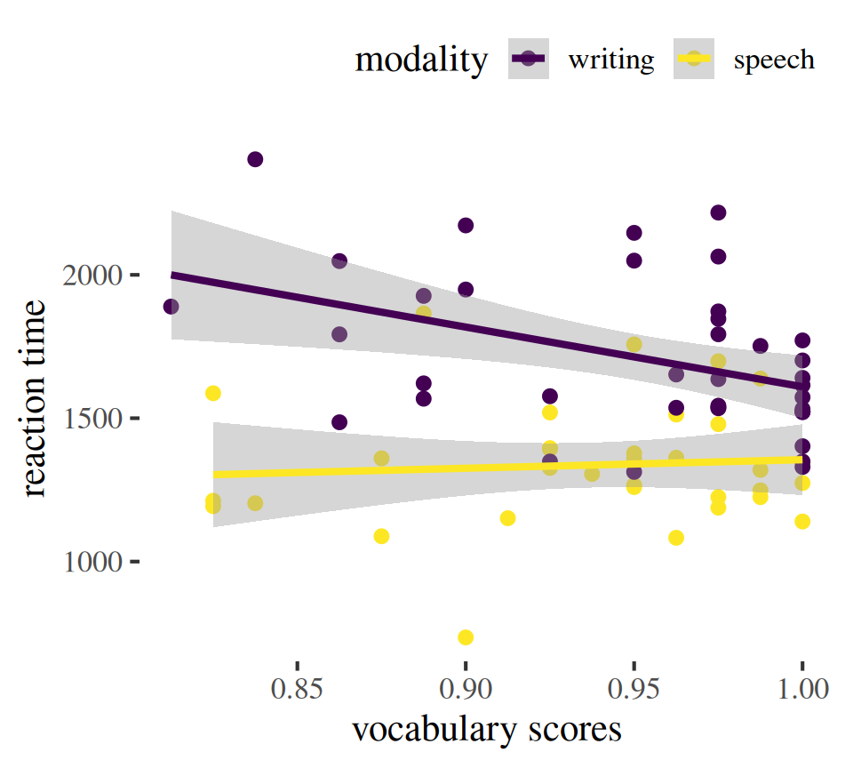

## Principles of data visualisation

**Principle 4:** Use Small Multiples

- Repeat charts across categories for comparison
- Supports pattern recognition

**Principle 5:** Encourage Visual Comparisons

- Design graphics to make comparisons easy
- Align scales and axes

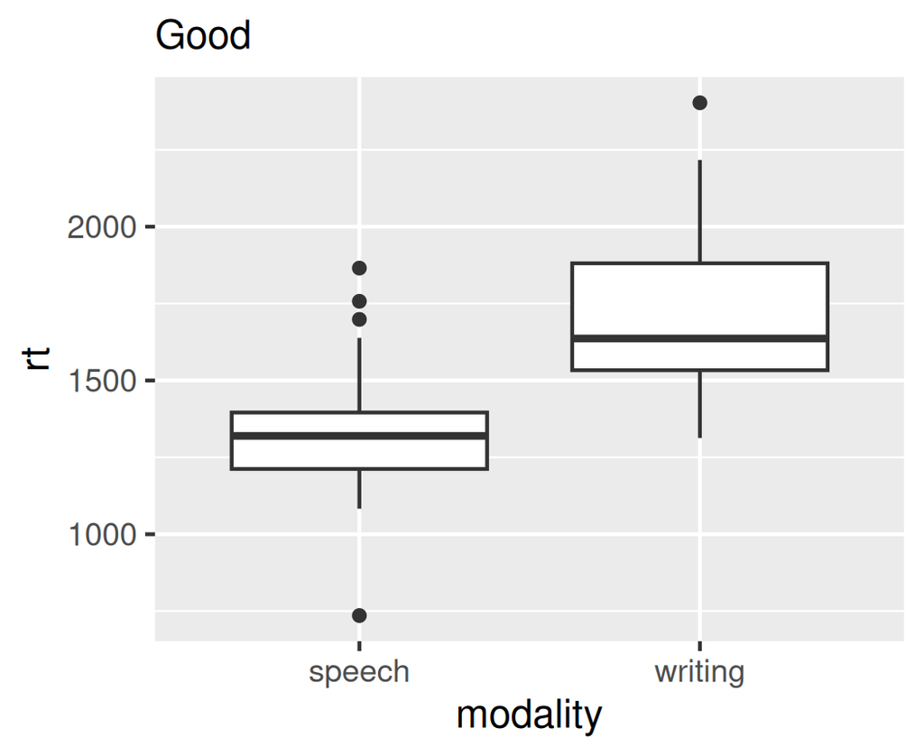

## Principles of data visualisation

**Principle 4:** Use Small Multiples

- Repeat charts across categories for comparison
- Supports pattern recognition

**Principle 5:** Encourage Visual Comparisons

- Design graphics to make comparisons easy
- Align scales and axes

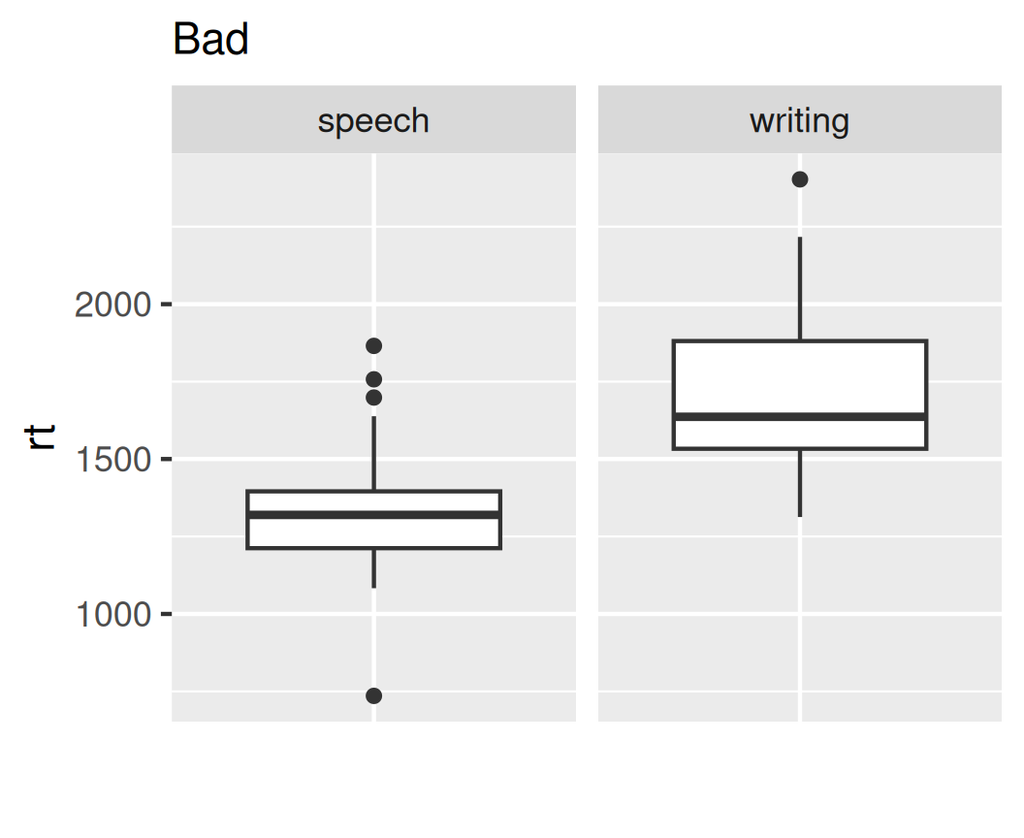

## Principles of data visualisation

**Principle 4:** Use Small Multiples

- Repeat charts across categories for comparison
- Supports pattern recognition

**Principle 5:** Encourage Visual Comparisons

- Design graphics to make comparisons easy
- Align scales and axes

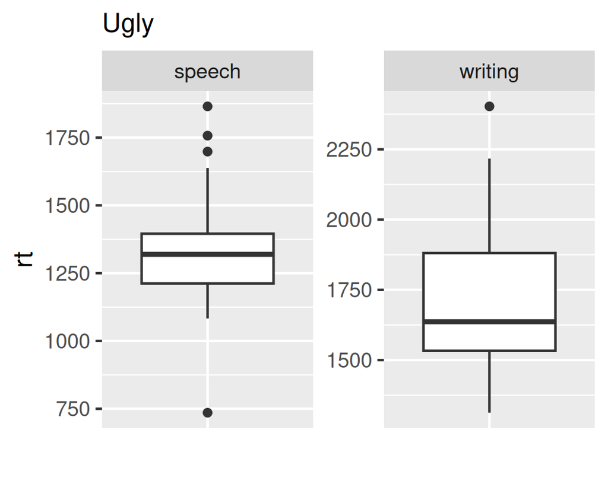

## Principles of data visualisation

**Principle 6:** Integrate Words, Numbers, and Images

- Labels should be clear and close to the data
- Avoid legends that require back-and-forth viewing

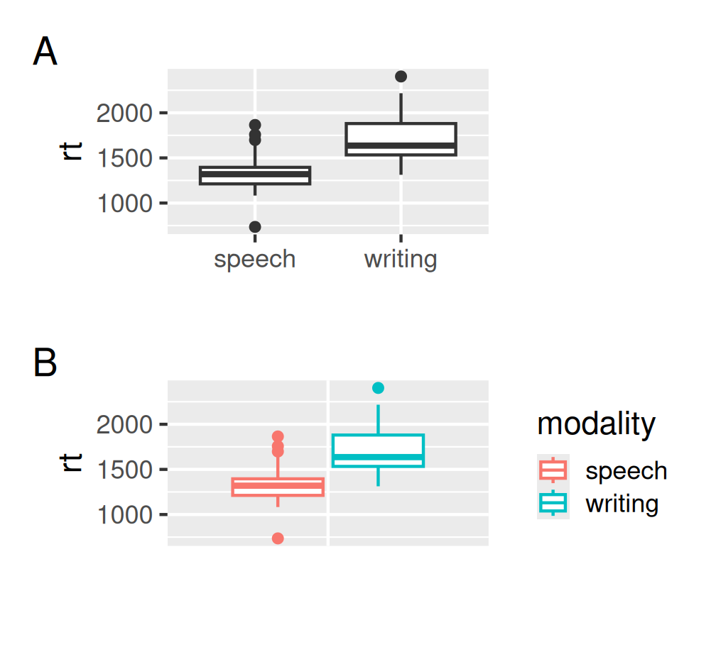

## Principles of data visualisation

**Principle 7:** Content Over Decoration

- Focus on substance, not style
- The story should come from the data

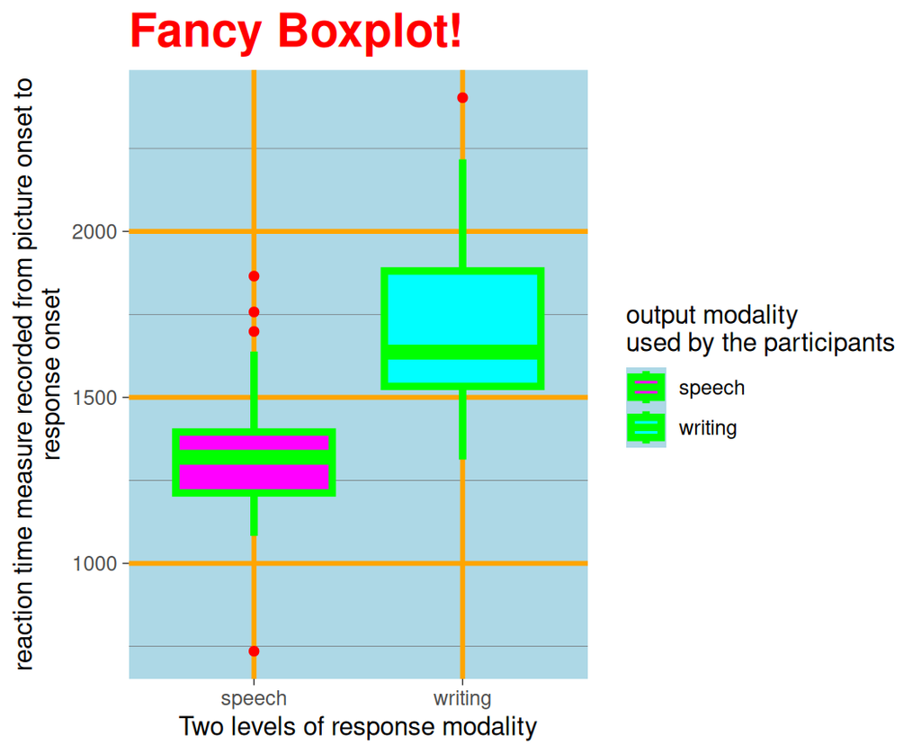

## Principles of data visualisation

**Principle 8:** Use Multivariate Displays

- Show multiple variables when appropriate
- Balance complexity with readability

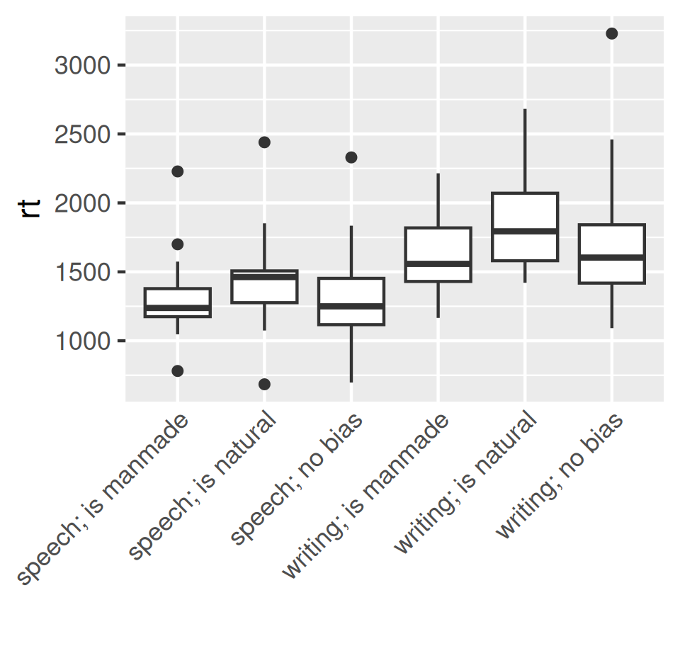

## Principles of data visualisation

**Principle 8:** Use Multivariate Displays

- Show multiple variables when appropriate
- Balance complexity with readability

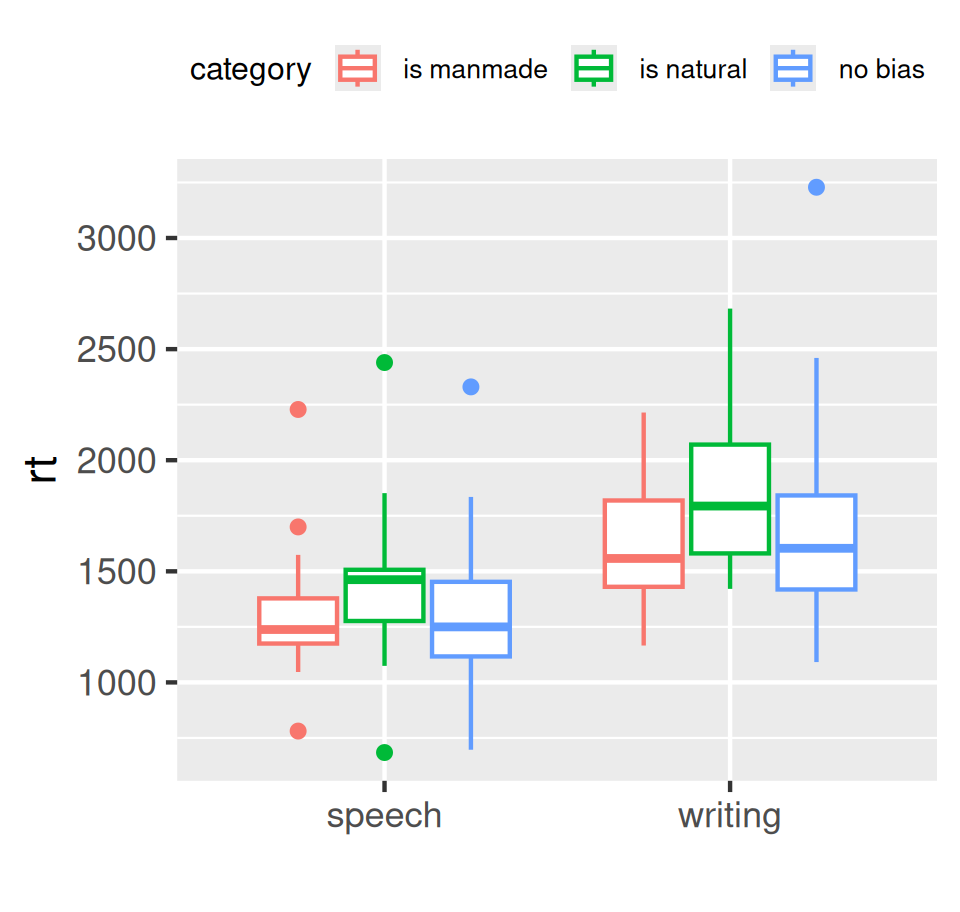

## Principles of data visualisation

**Principle 8:** Use Multivariate Displays

- Show multiple variables when appropriate
- Balance complexity with readability

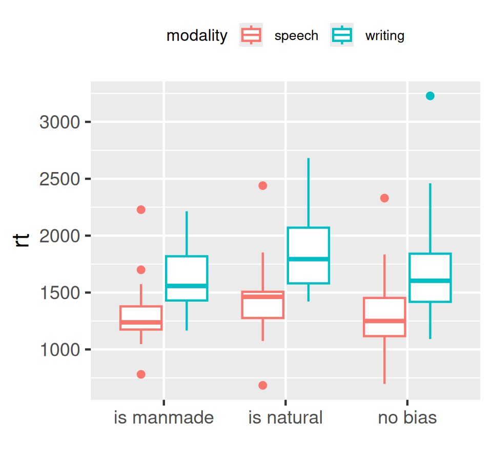

## Principles of data visualisation

**Principle 9:** Avoid Distorting the Data

- Maintain proportionality and scale
- Avoid misleading visuals

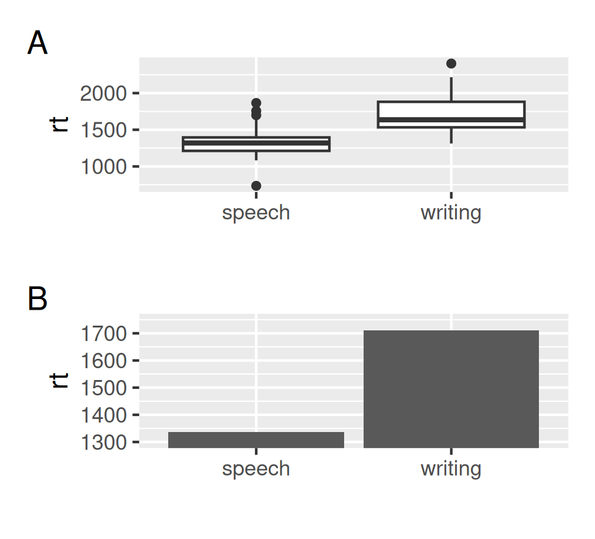

## Principles of data visualisation

- Clarity: Avoid clutter; make the message obvious
- Accuracy: Represent data truthfully
- Efficiency: Use the right chart for the right data
- Consistency: Use consistent scales, colors, and labels
- Accessibility: Consider colorblind-friendly palettes and readable fonts

## What’s wrong with these?

[figure not shown]

See Gong & Liu (2022) (now retracted), Rubiah et al. (2024), and Ke (2024) for examples.

Check Figures in [van Lieburg et al. (2023)](https://link.springer.com/article/10.1007/s41809-023-00131-5); code and data are [HERE](https://osf.io/x8ejm/).

## Reading

Next week we will continue with data visualisation in `ggplot2`. For fundamentals of data visualisation in `ggplot2` see

- [Chapter 4 of Andrews (2021)](https://github.com/mark-andrews/ddsr/releases/download/v22.7.31/chapter_04_visualization.pdf)
- [Chapter 3 of Wickham & Grolemund (2016)](https://r4ds.had.co.nz/data-visualisation.html)
- [Chapter 1 and 2 of Wickham (2016)](https://ggplot2-book.org/)
- [Wickham (2010)](https://vita.had.co.nz/papers/layered-grammar.html)

And for principles of data visualisation see this book: [Tufte (2001)](https://llr.primo.exlibrisgroup.com/permalink/44NTU_INST/16gp82k/alma990004565400107181)

## Homework

Identify a dataset for the formative assessment.

On Teams, share a poor data visualisation (from a published research papers, news websites, social media, etc) and your reason why it is poor. Which principle(s) of data visualisation were violated?

## References

Andrews, M. (2021). *Doing data science in R: An introduction for Social Scientists*. SAGE Publications Ltd.

Anscombe, F. J. (1973). Graphs in statistical analysis. *The American Statistician*, *27*, 17–21.

Gong, R., & Liu, B. (2022). [Retracted] monitoring of sports health indicators based on wearable nanobiosensors. *Advances in Materials Science and Engineering*, *2022*(1), 3802603. https://doi.org/https://doi.org/10.1155/2022/3802603

Hartwig, F., & Dearing, B. E. (1979). *Exploratory data analysis*. Sage.

Ke, Y. (2024). Examining simultaneous pausing on the cognitive writing process: A micro-formative writing assessment. *Current Psychology*, *43*(1), 39–50.

Matejka, J., & Fitzmaurice, G. (2017). Same stats, different graphs: Generating datasets with varied appearance and identical statistics through simulated annealing. *Proceedings of the 2017 CHI Conference on Human Factors in Computing Systems*, 1290–1294.

Rubiah, R., Degeng, I. N. S., Setyosari, P., & Kuswandi, D. (2024). The effect of problem-based learning assisted with concept mapping founded on cognitive style on the creativity of writing exposition text. *Creativity Studies*, *17*(2), 419–434.

Tufte, E. R. (1983). *The visual display of information*. Graphics Press.

Tufte, E. R. (2001). *The visual display of quantitative information* (2nd ed.). Graphics Press.

Tukey, J. W. (1977). *Exploratory data analysis* (Vol. 2).

van Lieburg, R., Sijyeniyo, E., Hartsuiker, R. J., & Bernolet, S. (2023). The development of abstract syntactic representations in beginning L2 learners of Dutch. *Journal of Cultural Cognitive Science*, *7*, 289–309. https://doi.org/10.1007/s41809-023-00131-5

Wickham, H. (2010). A layered grammar of graphics. *Journal of Computational and Graphical Statistics*, *19*(1), 3–28.

Wickham, H. (2016). *ggplot2: Elegant graphics for data analysis*. Springer.

Wickham, H., & Grolemund, G. (2016). *R for data science: Import, tidy, transform, visualize, and model data*. O’Reilly Media, Inc.